# L’Oeil du 20h

## Etat des lieux de la vaccination en France

Ce “markdown” est dedie a la datavisualisation des donnees sur la vacination contre le COVID-19.

Le but : voir si la vaccination privilegie un groupe de personnes et si les departements d’Outre-mer sont laisses de cote.

#### Ci-dessous, les sources pour les données de vaccination :

```r
# Liens de telechargement vers les donnees de data.gouv.fr

#nombre quotidien de residents en EHPAD ayant reçu au moins une dose ou deux doses, par date d'injection
url1 <- "https://www.data.gouv.fr/fr/datasets/r/72d3b91e-ef24-4c91-a3c3-52b72d418000"
#nombre de residents en EHPAD ayant reçu au moins une dose ou deux doses ainsi que la couverture vaccinale, arrete a la derniere date disponible
url2 <- "https://www.data.gouv.fr/fr/datasets/r/104f3ab1-de0f-41c5-9bd8-edab9926882c"
#nombre quotidien de personnes ayant reçu au moins une dose, par classes d'age, et par date d'injection
url3 <- "https://www.data.gouv.fr/fr/datasets/r/54dd5f8d-1e2e-4ccb-8fb8-eac68245befd"
#nombre de personnes ayant reçu au moins une dose ou deux doses, par classes d'age, arrete a la derniere date disponible
url4 <- "https://www.data.gouv.fr/fr/datasets/r/dc103057-d933-4e4b-bdbf-36d312af9ca9"
#nombre de personnes ayant reçu au moins une dose ou deux doses, par classes d'age, arrete a la derniere date disponible, echelle regionale
url5 <- "https://www.data.gouv.fr/fr/datasets/r/2dadbaa7-02ae-43df-92bb-53a82e790cb2"
#nombre de residents en EHPAD ayant re?u au moins une dose ou deux doses ainsi que la couverture vaccinale, arrete la derniere date disponible, echelle regionale
url6 <-"https://www.data.gouv.fr/fr/datasets/r/5cb5a964-a8f7-4111-b527-1a2d48dee3d4"
#nombre de personnes testées et le nombre de personnes déclarées positives par sexe et classe d'âge
url7 <- "https://www.data.gouv.fr/fr/datasets/r/dd0de5d9-b5a5-4503-930a-7b08dc0adc7c"
#nombre de personnes ayant reçu au moins une dose, par classes d’age, arrete a la dernière date disponible, echelle departementale
url8 <- "https://www.data.gouv.fr/fr/datasets/r/de4b356b-8cd9-4b9a-8878-459a62646107"
#nombre de résidents en EHPAD ayant reçu au moins une dose ou deux doses ainsi que la couverture vaccinale, echelle departementale
url9 <- "https://www.data.gouv.fr/fr/datasets/r/1cbfd282-e882-479d-afcc-958f09f617ec"
#livraisons départementales réalisées et prévisionnelles par semaine, en UCD (flacons) et doses comptabilisées comme la somme des différents flux départementaux
url10 <- "https://www.data.gouv.fr/fr/datasets/r/d9ad34ee-2d05-4f40-965b-9ba40a7d5f83"
```

#### Attention : la seconde dose ne figure pas toujours dans data.gouv.fr !

Il faut retrouver ces donnees sur Geodes et les ajouter au tableau.

Geodes propose le total des secondes injections par jour. Les récuperer se fait largement a la main.

## Carte des livraisons de vaccins

####Chiffres cumules de livraisons, tous vaccins confondus.

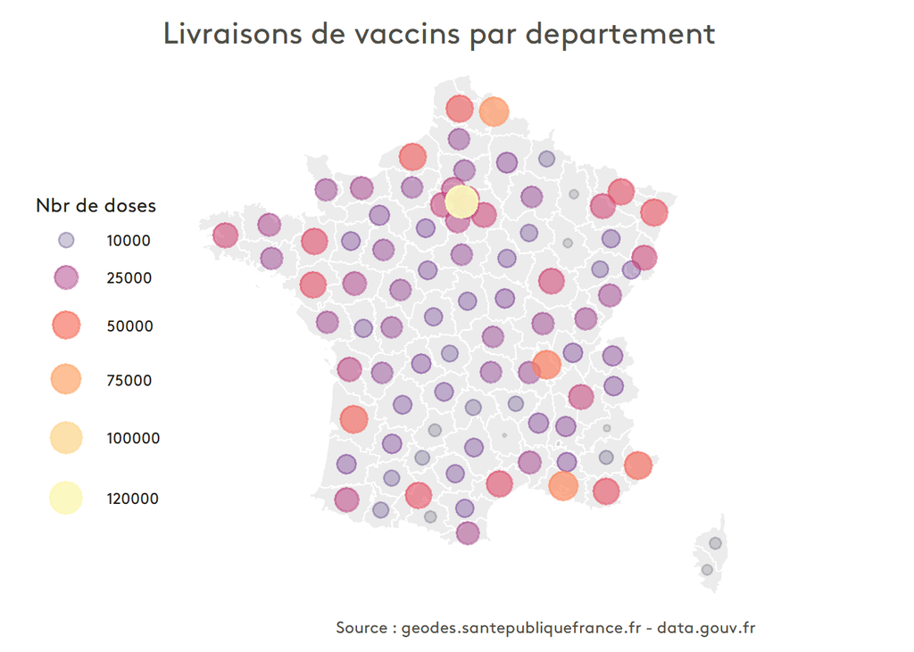

## Courbes de la campagne de vaccination dose 1 (valeurs absolues)

La vaccination pour la dose 1 a commence le 27 decembre 2020 en ordre plutot disperse.

Une ligne verticale noire délimite l’introduction du vaccin AstraZeneca. Celui-ci, privilegie pour les publics plus jeunes, change la lecture des donnees.

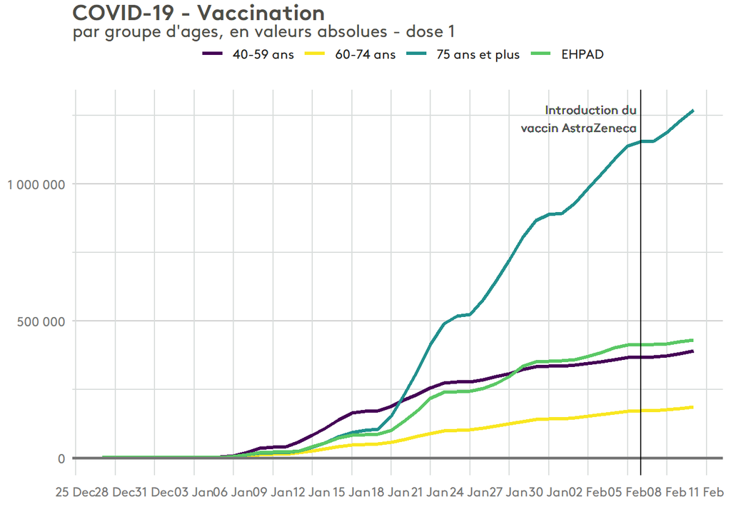

## Courbes de la campagne de vaccination dose 2 (valeurs absolues)

L’administration de la deuxieme dose a commence le 26 janvier.

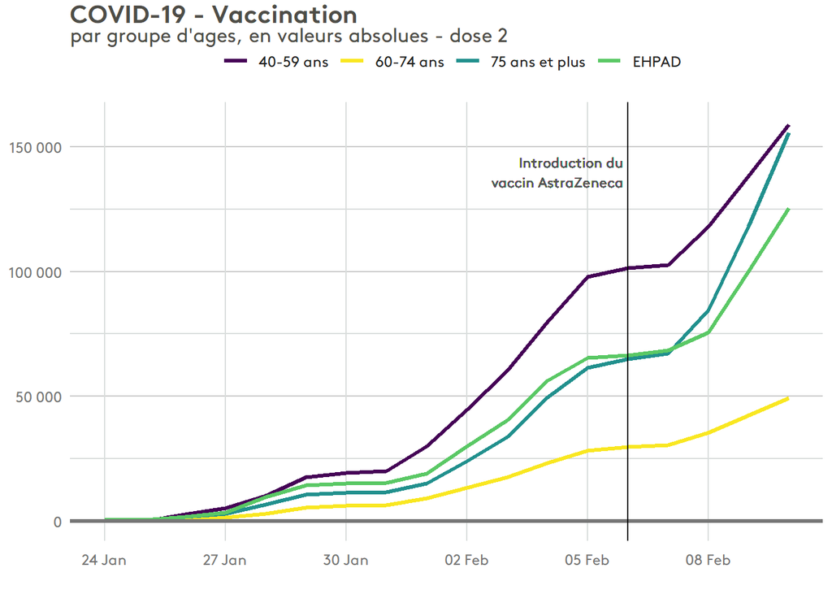

## Superposition des deux graphiques

Alignement des courbes des doses 1 et 2 pour comparer le suivi des injections

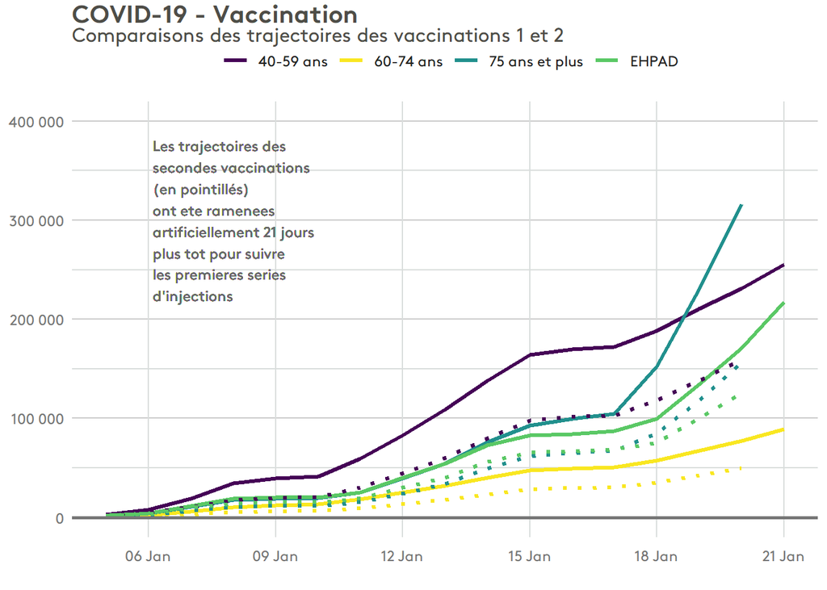

## Part de la dose 2 par rapport a la dose 1

Ce graphique représente la part de doses 2 par rapport à la dose 1 par groupe d’age, au niveau national.

Encore une fois, la campagne de seconde dose a ete plus genereuse avec les 40-59 ans… beaucoup mois avec les 75 ans et plus.

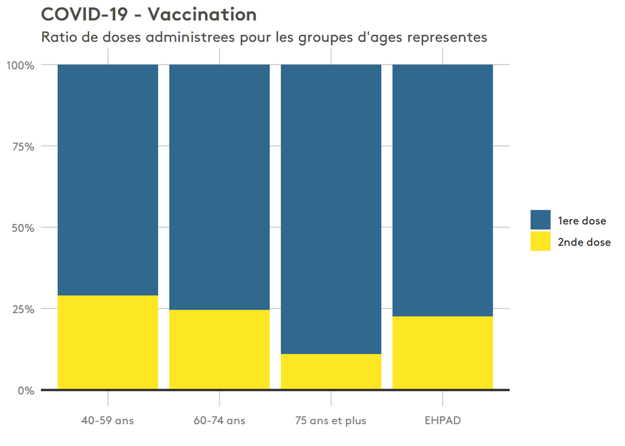

## Analyse en proportion de la population

Les graphiques en % permettent de mettre chaque region et chaque tranche d’age au meme niveau.

Cette etape est delicate car les groupes d’ages sont repartis differemment sur l’INSEE (donnees de population) et sur data.gouv (donnees de vaccination).

Donc il y a pas mal de netoyage de donnees a faire en amont.

### Donnees departemantales

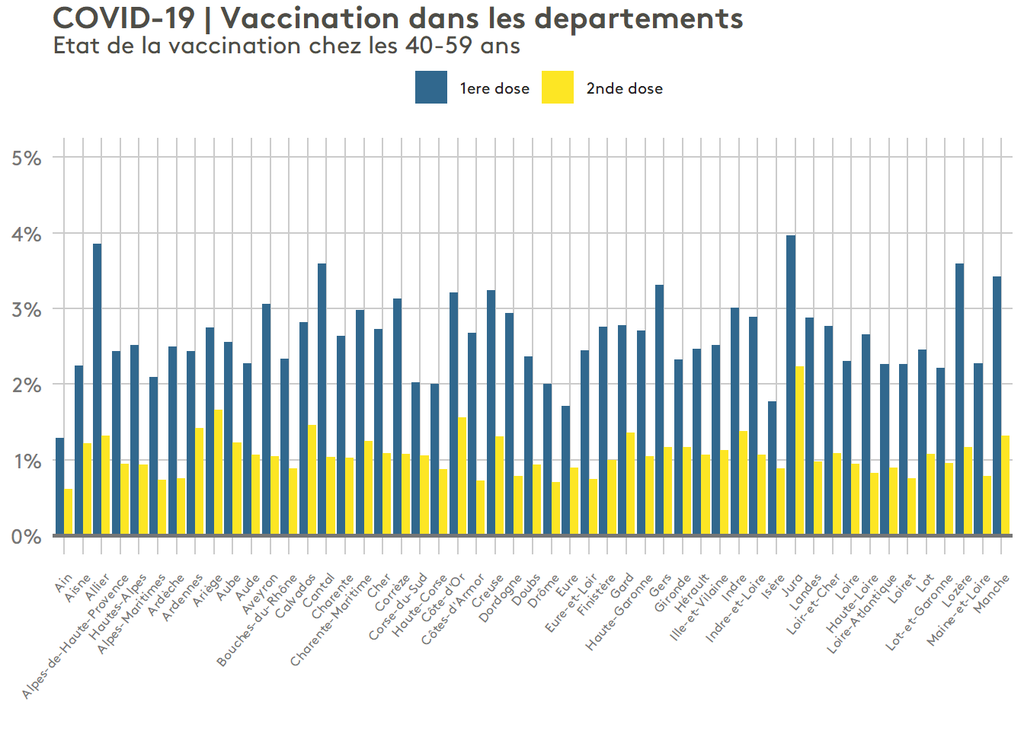

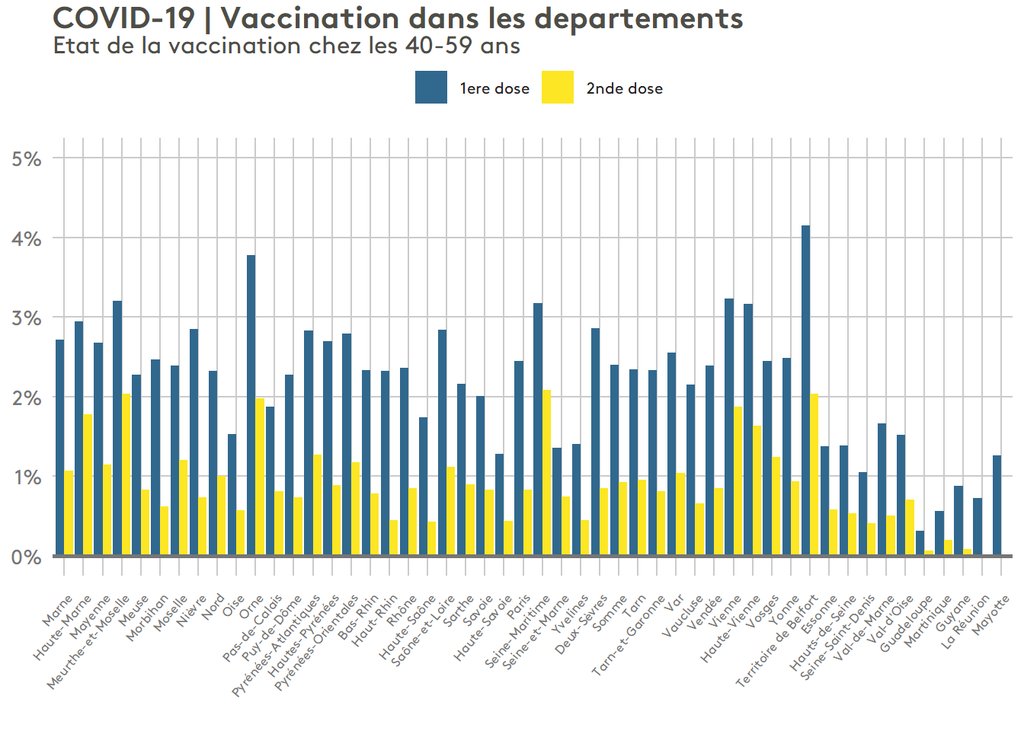

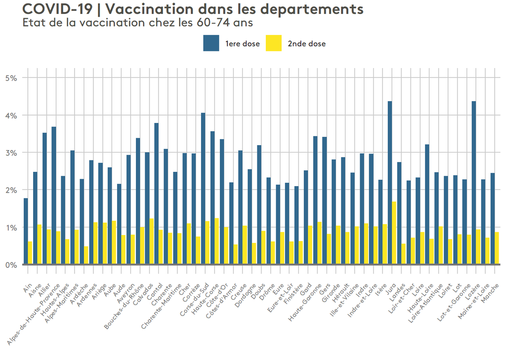

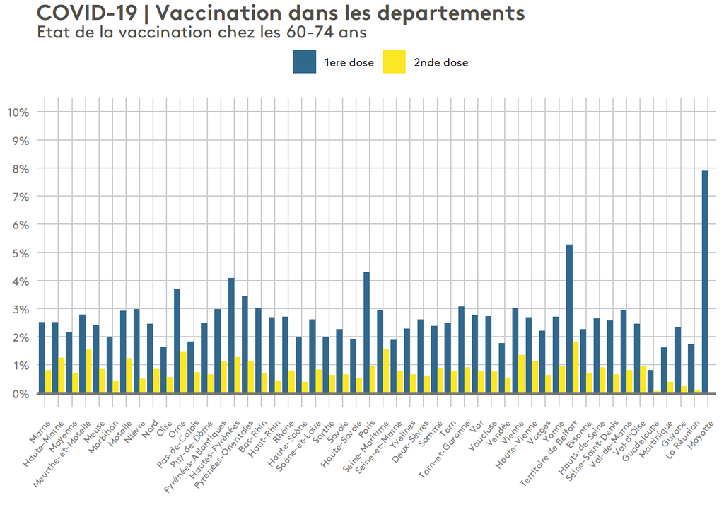

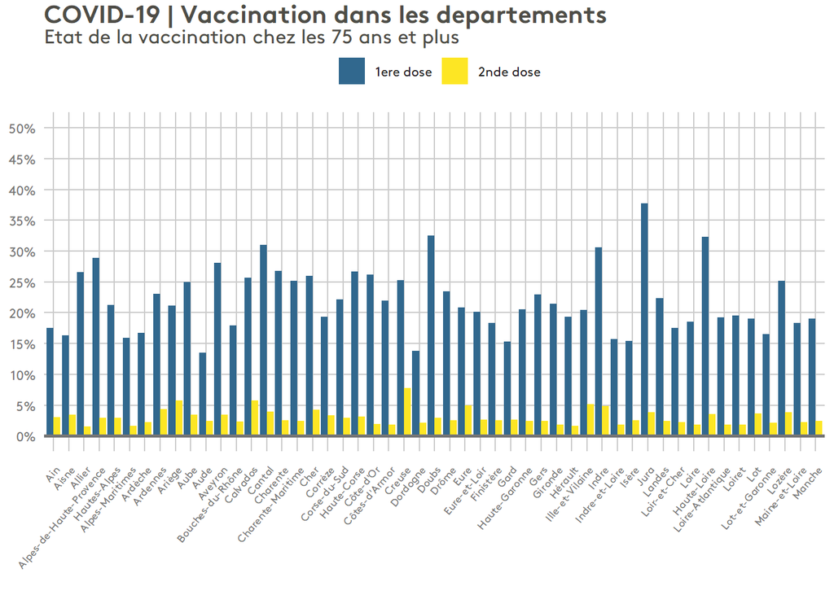

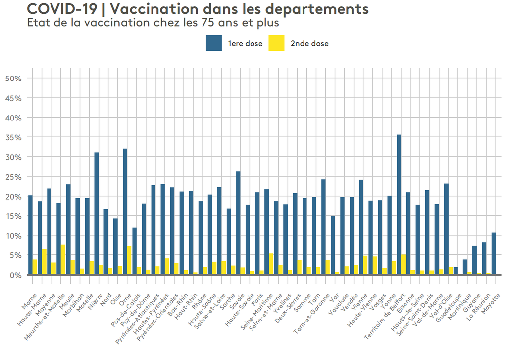

### Donnees regionales

Le graphique ci-dessous montre que, proportionnellement à leur population, les territoires d’Outre-mer ont reçu moins de vaccins, doses 1 et 2 confondues.

On constate aussi des disparites entre les regions.

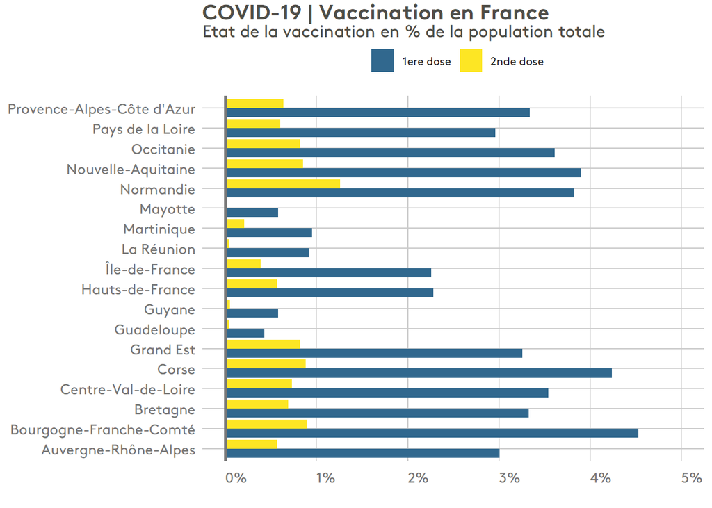

Plus en détail, le groupe des 40-59 ans apparait homogene et la seconde injection semble bien suivre la premiere.

Bien que pour chaque region, moins de 3% des 40-59 ans sont accines (au 5 fevrier).

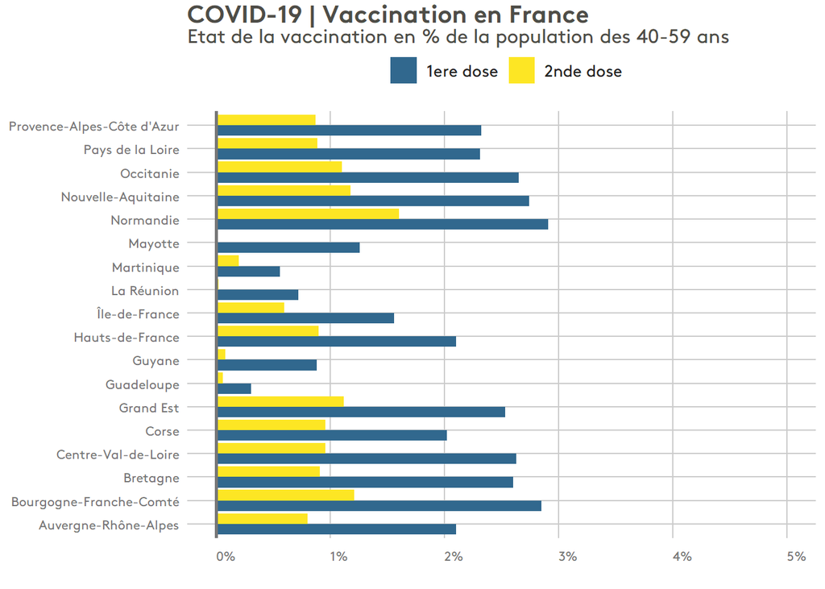

La deuxieme injection suit moins rapidement la premiere pour les 60-74 ans.

Surtout à Mayotte, ou plus de 3% de ce groupe a recu la premiere dose et presque personne n’a recu la seconde.

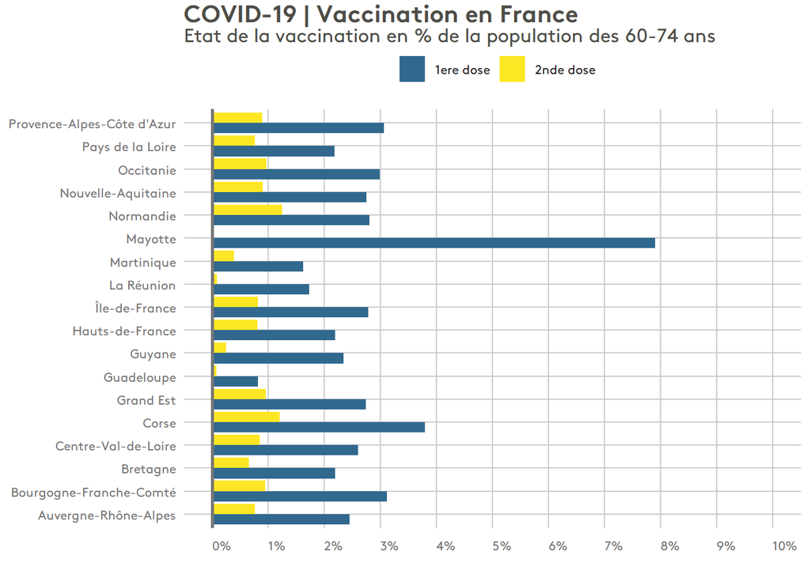

Le ratio est encore plus large dans le groupe des plus de 75 ans.

Notez que l’echelle a change et va de 0 a 30%.

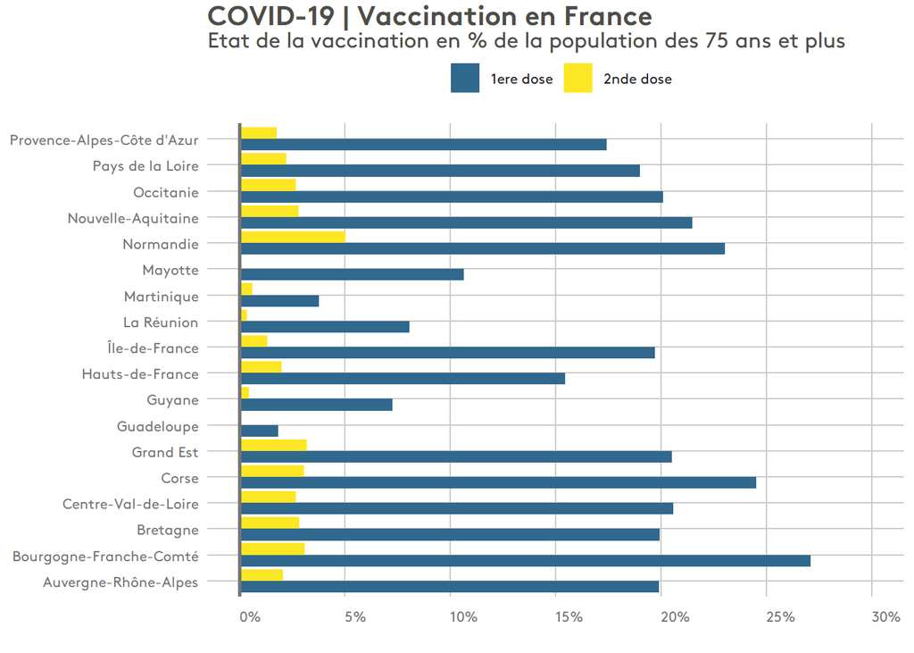

L’etat de la vaccination est bien avance dans les EHPAD avec presque 100% des residents corses ayant recu la premiere dose.

Pourtant dans les EHPAD d’Outre-mer, et particulierement en Guadeloupe et en Guyane, l’ecart est tres marque entre la premiere et la seconde injection.

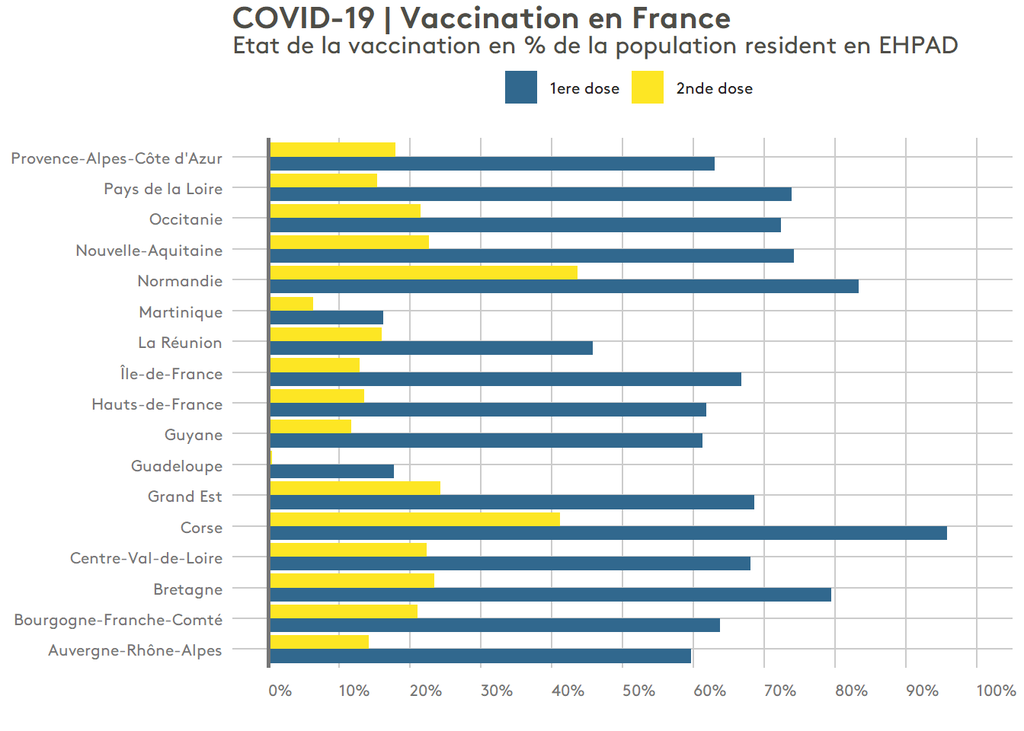

## Part des soignants de 50 ans et plus dans la population

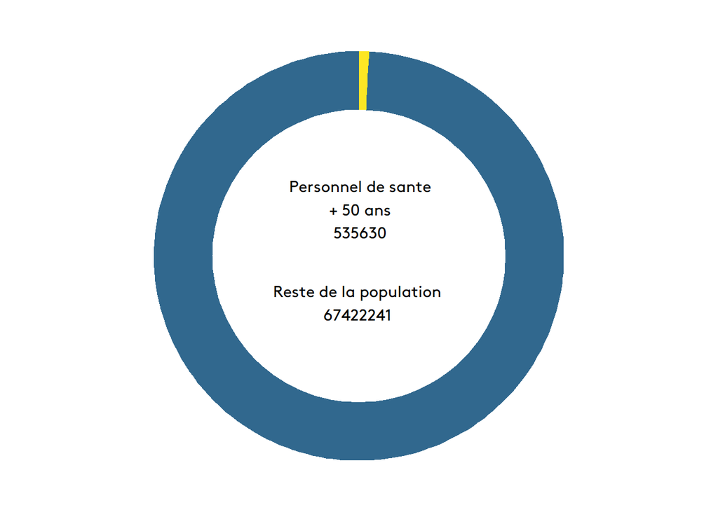

## Evolution du taux d’incidence par groupe d’ages

Le taux d’incidence moyen hebdomadaire reste eleve chez les + de 80 ans.

*Taux d’incidence = nombre de cas positifs pour 100 000 personnes par semaine.

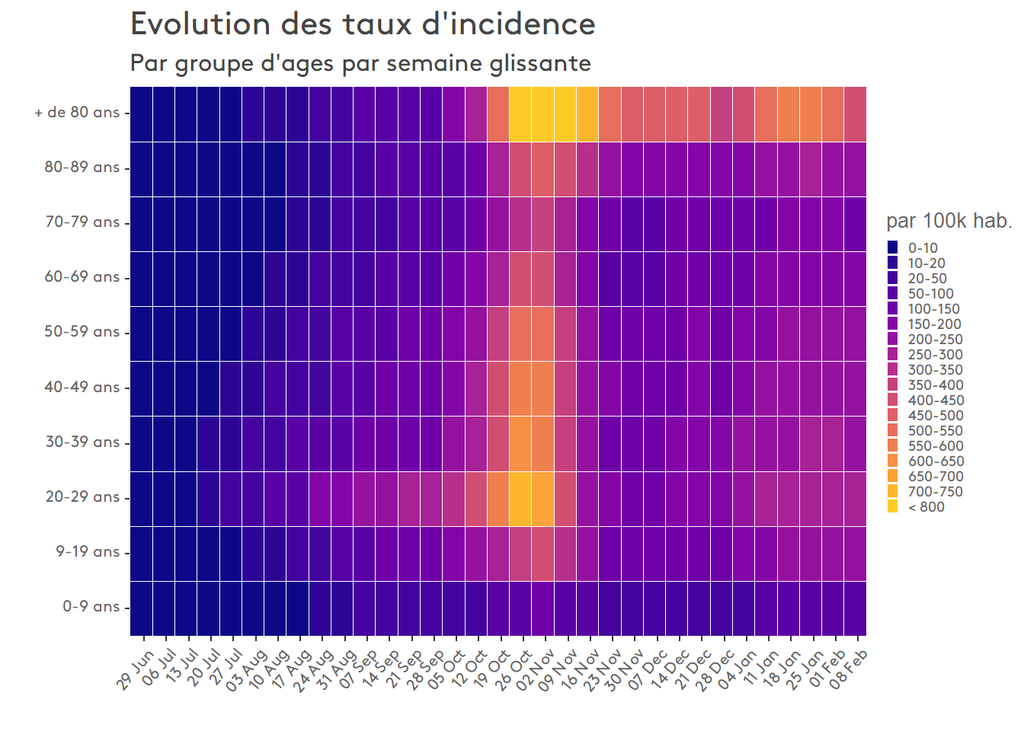